# Transformaciones territoriales y usos del suelo entre 2008 y 2017

María Emilia Persico

Junio 2019

## Introducción

El relevamiento de usos del suelo (RUS) consiste en una completa base con las características tipológicas de la edificación y los usos reales en cada parcela de la ciudad. A partir de esta información se pueden generar estadísticas y material cartográfico que permiten la realización de análisis espaciales y que, al cruzarse con otras bases de datos, resultan en un importante insumo para el diseño de políticas urbanas. Entre el año 2008 y 2017 se realizaron tres relevamientos de los usos del suelo en la ciudad de Buenos Aires : el primero en 2008, el segundo en 2011 y el tercero en 2017. Al existir tres cortes temporales, no solo resulta útil para realizar análisis sincrónicos, sino también para estudiar la dinámica y evolución de los usos reales de la ciudad, detectando las zonas con mayor nivel de transformación.

El objetivo principal de este estudio, es por lo tanto, realizar un análisis exploratorio de las principales transformaciones en los usos reales de la ciudad de Buenos Aires entre los años 2008 y 2017. Se buscan responder las siguientes preguntas de investigación:

- ¿Cuáles son los usos reales que experimentaron cambios?
- ¿Cuáles son las zonas con mayor intensidad de cambios? ¿Se pueden detectar zonas singulares de transformación?
- ¿Existe algún tipo de transformación predominante que indique un cambio de carácter en el modo de producir el hábitat?

### Datos empleados

Para el análisis se utilizaron las siguientes bases de datos, extraídas del portal de datos abiertos [Buenos Aires Data](https://data.buenosaires.gob.ar/:)

- relevamiento-usos-del-suelo-2008.csv
- relevamiento-usos-del-suelo-2017.csv
- relevamiento-usos-del-suelo-2016-2017.shp

### Metodología

El estudio se realizó de acuerdo a las siguientes etapas:

1.Análisis, limpieza y ajustes de la base de relevamiento de usos del suelo 2008.Agrupación de los usos reales en categorías simplificadas.

2.Análisis, limpieza y ajustes de la base de relevamiento de usos del suelo 2017.Agrupación de los usos reales en categorías simplificadas.

3.Comparación de las bases resultantes en 1 y 2 a fin de detectar las parcelas que experimentaron cambios.

4.Georreferenciación de las parcelas que experimentaron cambios.

5.Evaluación y síntesis de los cambios principales detectados.

## Resultados

Se analiza primero la base correspondiente al RUS 2008 y luego la del RUS 2017. Se hacen ajustes y limpieza de los datos. Cada una de estas bases es agregada por SMP para luego ser unidas en una única base a partir de la cuál se evalúa si cada parcela tuvo o no un cambio de usos.Una vez detectadas las parcelas con algún tipo de cambio de uso, se analizan los tipos de cambios principales (qué uso reemplazó a cuál) y se analiza su distribución espacial mediante mapas de calor.

### RUS 2008

En este apartado se muestran los procesos de limpieza, ajuste y armado de categorías para la base del RUS 2008.Se trabaja sobre la base *relevamiento-usos-del-suelo-2008.csv*.

#### Ajustes RUS 2008

- Selección de las columnas de interés

```r
rus2008_1 <- select(rus2008,SMP, BARRIO, TIPO_1, TIPO_2,PISOS)
```

- Renombrado de los columnas para facilitar la unión con la base del RUS 2017.

```r
names(rus2008_1)<-c("smp","BARRIO_08","TIPO_1_08","TIPO_2_08","PISOS_08")
```

- Corrección de la nomenclatura catastral. Se agrega el cero faltante a la sección en el smp para el RUS 2008.

```r
rus2008_1$smp = paste(rep (0, 1),rus2008_1$smp , sep ="")
```

- Corrección de errores de tipeo en las columnas TIPO_1_08 y TIPO_2_08

```r
rus2008_1$TIPO_1_08[rus2008_1$TIPO_1_08 == " L "] <- "L"
```

```r
rus2008_1$TIPO_1_08[rus2008_1$TIPO_1_08 == "GAP "] <- "GAP"
```

```r
rus2008_1$TIPO_1_08[rus2008_1$TIPO_1_08 == " GAP"] <- "GAP"
```

```r
rus2008_1$TIPO_1_08[rus2008_1$TIPO_1_08 == "GAP"] <- "GAP"
```

```r
rus2008_1$TIPO_1_08[rus2008_1$TIPO_1_08 == "p"] <- "P"
```

```r
rus2008_1$TIPO_1_08[rus2008_1$TIPO_1_08 == "p"] <- "P"
```

```r
rus2008_1$TIPO_1_08[rus2008_1$TIPO_1_08 == " E "] <- "E"
```

```r
rus2008_1$TIPO_1_08[rus2008_1$TIPO_1_08 == "U "] <- "U"
```

```r
rus2008_1$TIPO_1_08[rus2008_1$TIPO_1_08 == "U "] <- "U"
```

```r
rus2008_1$TIPO_1_08[rus2008_1$TIPO_1_08 == "U"] <- "UNIF"
```

#### Armado de categorías de usos.

Dado que el RUS cuenta con casi 700 tipos de usos distintos se agrupan en 12 tipos principales:

- Residencial unifamiliar
- Residencial multifamiliar
- Edificio productivo, oficina y/o deposito
- Equipamiento
- Comercio
- En obra o terreno vacío
- Puesto en vía publica
- Cerrado y/o abandonado
- Garage privado
- Parcela interna
- Unificación de parcela
- villa

```r
rus2008_1 <- rus2008_1 %>%
  mutate(CATEGORIA_08 = case_when(
    TIPO_2_08 == "VU - VIVIENDA UNICA" ~ "Residencial unifamiliar",
    TIPO_2_08 == "DEPARTAMENTOS" ~ "Residencial multifamiliar",
    TIPO_2_08 == "VIVIENDA" ~ "Residencial multifamiliar",
    TIPO_2_08 == "CASA" ~ "Residencial unifamiliar",
    TIPO_2_08 == "OFICINAS" ~ "Edificio productivo, oficina y/o deposito",
    TIPO_2_08 == "ABANDONADO" ~ "Cerrado y/o abandonado",
    TIPO_2_08 == "CERRADO" ~ "Cerrado y/o abandonado",
    TIPO_2_08 == "CLAUSURADO" ~ "Cerrado y/o abandonado",
    TIPO_2_08 == "CLUB" ~ "Equipamiento",
    TIPO_2_08 == "EDU" ~ "Equipamiento",
    TIPO_2_08 == "GARAGE PRIVADO" ~ "Garage privado",
    TIPO_2_08 == "GERIATRICO" ~ "Equipamiento",
    TIPO_2_08 == "EN OBRA" ~ "En obra o terreno vacio",
    TIPO_2_08 == "OBRA SOCIAL" ~ "Edificio productivo, oficina y/o deposito",
    TIPO_2_08 == "OFICINAS" ~ "Edificio productivo, oficina y/o deposito",
    TIPO_2_08 == "PARCELA INTERNA" ~ "Parcela interna",
    TIPO_2_08 == "SU - USO UNICO" ~ "Comercio",
    TIPO_2_08 == "TALLER ELECTRONICA AUTOMOTORES" ~ "Edificio productivo, oficina y/o deposito",
    TIPO_2_08 == "U E" ~ "Residencial",
    TIPO_2_08 == "U EDU" ~ "Equipamiento",
    TIPO_2_08 == "U EP" ~ "Edificio productivo, oficina y/o deposito",
    TIPO_2_08 == "U ES" ~ "Equipamiento",
    TIPO_2_08 == "U G" ~ "Edificio productivo, oficina y/o deposito",
    TIPO_2_08 == "U GA" ~ "Edificio productivo, oficina y/o deposito",
    TIPO_2_08 == "U GAP" ~ "Garage privado",
    TIPO_2_08 == "U L" ~ "Comercio",
    TIPO_2_08 == "U LOTE" ~ "En obra o terreno vacio",
    TIPO_2_08 == "VILLA" ~ "Villa",
    TIPO_1_08 == "EDU" ~ "Equipamiento",
    TIPO_1_08 == "EP" ~ "Edificio productivo, oficina y/o deposito",
    TIPO_1_08 == "ES" ~ "Equipamiento",
    TIPO_1_08 == "G" ~ "Edificio productivo, oficina y/o deposito",
    TIPO_1_08 == "GA" ~ "Edificio productivo, oficina y/o deposito",
    TIPO_1_08 == "GAP" ~ "Garage privado",
    TIPO_1_08 == "L" ~ "Comercio",
    TIPO_1_08 == "LG" ~ "Comercio",
    TIPO_1_08 == "LOTE" ~ "En obra o terreno vacio",
    TIPO_1_08 == "P" ~ "Puesto en via publica",
    TIPO_1_08 == "SU" ~ "Comercio",
    TIPO_1_08 == "SU" ~ "Comercio",
    TIPO_1_08 == "UNIF" ~ "Unificacion de parcela"))
```

Se observa la distribución para cada categoría armada:

```
##
##                    Cerrado y/o abandonado
##                                      3869
##                                  Comercio
##                                    126187
## Edificio productivo, oficina y/o deposito
##                                     20638
##                   En obra o terreno vacio
##                                      9954
##                              Equipamiento
##                                     14289
##                            Garage privado
##                                    114251
##                           Parcela interna
##                                         2
##                     Puesto en via publica
##                                      2839
##                               Residencial
##                                      1006
##                 Residencial multifamiliar
##                                    142397
##                   Residencial unifamiliar
##                                    121515
##                    Unificacion de parcela
##                                        77
##                                     Villa
##                                       308
```

Dado que no todas las categorías armadas revelan un tipo de uso concreto, sino que aportan algún tipo de información adicional o bien son consecuencia de algún error de relevamiento, se extraen únicamente aquellas categorías que nos permiten evaluar los usos reales principales:

- Residencial unifamiliar
- Residencial multifamiliar
- Edificio productivo, oficina y/o deposito
- Equipamiento
- Comercio
- En obra o terreno vacío
- Cerrado y/o abandonado

```r
rus2008_3 <- subset(rus2008_2,CATEGORIA_08 == "Cerrado y/o abandonado"|
                    CATEGORIA_08 == "Edificio productivo, oficina y/o deposito"|
                    CATEGORIA_08 == "Equipamiento"|
                    CATEGORIA_08 == "Residencial multifamiliar"|
                    CATEGORIA_08 == "En obra o terreno vacio"|
                    CATEGORIA_08 == "Comercio"|
                    CATEGORIA_08 == "Residencial unifamiliar")
```

- Vemos los resultados obtenidos:

```
##
##                    Cerrado y/o abandonado
##                                      3869
##                                  Comercio
##                                    126187
## Edificio productivo, oficina y/o deposito
##                                     20638
##                   En obra o terreno vacio
##                                      9954
##                              Equipamiento
##                                     14289
##                 Residencial multifamiliar
##                                    142397
##                   Residencial unifamiliar
##                                    121515
```

- Se analizan los resultados mediante gráfico de barras:

```r
categorias_2008 <- rus2008_3 %>%
  group_by(CATEGORIA_08) %>%
  summarise(cantidad_08 = n()) %>%
  mutate (total_08=sum(cantidad_08)) %>%
  mutate(porcentaje_08= (cantidad_08*100)/total_08) %>%
  arrange(desc(porcentaje_08))
```

```r
names(categorias_2008)<-c("categoria", "cantidad_08", "total_08","porcentaje_08")
```

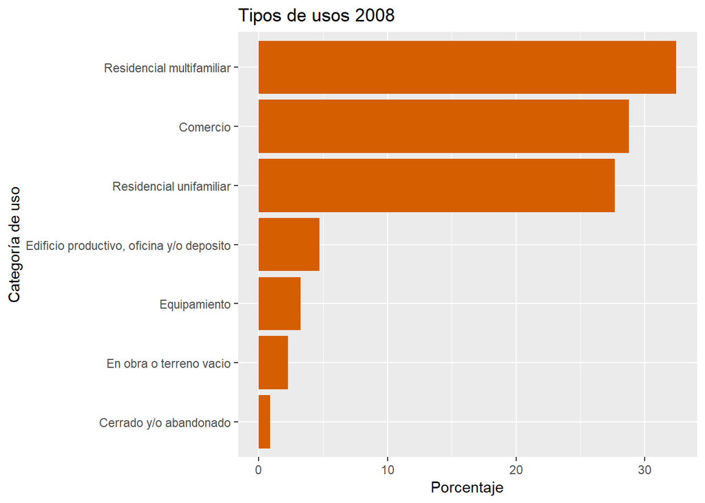

```r
ggplot(categorias_2008, aes(x=reorder(categoria, porcentaje_08), y= porcentaje_08)) +
  geom_bar(stat="identity", fill="#D55E00")+
  coord_flip()+
  labs(title = "Tipos de usos 2008",
         x = "Categoría de uso",
         y = "Porcentaje")
```

#### Agrupación de usos por parcelas (smp)

El relevamiento de usos del suelo cuenta con un registro para cada tipo de uso encontrado en una parcela. Para poder realizar la comparación resulta necesario tener todos los usos en un único registro por parcela.

```r
rus08_parcela_1 <- rus2008_3 %>%
  group_by(smp) %>%
  summarise(cant = n(), pisos08 = mean(PISOS_08), barrio08 = first(BARRIO_08),
  CATEGORIA_08_GROUP= paste(sort(unique(CATEGORIA_08)), collapse = ","))
```

La tabla resultante queda del siguiente modo:

Usos 2008 agrupados por parcela.

| smp | cant | pisos08 | barrio08 | CATEGORIA_08_GROUP |
| --- | --- | --- | --- | --- |
| 001-002-020A | 1 | 7.000000 |  | Equipamiento |
| 001-002-021C | 6 | 2.333333 |  | Comercio,Edificio productivo, oficina y/o deposito |
| 001-002-022 | 2 | 2.000000 |  | Comercio |
| 001-002-023 | 2 | 2.500000 |  | Comercio,Edificio productivo, oficina y/o deposito |
| 001-002-024B | 1 | 3.000000 |  | Equipamiento |
| 001-002-027 | 1 | 2.000000 |  | Equipamiento |
| 001-002-028 | 2 | 2.500000 |  | Comercio,Residencial multifamiliar |
| 001-002-029 | 1 | 5.000000 |  | Equipamiento |
| 001-002-030 | 2 | 3.500000 |  | Comercio,Residencial multifamiliar |
| 001-002-031 | 2 | 4.500000 |  | Comercio,Residencial multifamiliar |
| 001-003A-001 | 2 | 5.000000 |  | Comercio,Edificio productivo, oficina y/o deposito |

### RUS 2017

En este apartado se muestran los procesos de limpieza, ajuste y armado de categorías para la base del RUS 2017.Se trabaja con la base *relevamiento-usos-del-suelo-2017.csv*.

#### Ajustes RUS 2017

- Selección de las columnas de interés

```r
rus2017_1 <- select(rus2017,smp,barrio, tipo1_16, tipo2_16, pisos_16)
```

- Renombrado de los columnas para facilitar la unión con la base del RUS 2008.

```r
names(rus2017_1)<-c("smp","BARRIO_17","TIPO_1_17","TIPO_2_17","PISOS_17")
```

#### Armado de categorías de usos.

Al igual que el RUS 2008, el RUS 2017 cuenta con casi 700 tipos de usos distintos, por lo que se agrupan en 10 tipos principales:

- Residencial unifamiliar
- Residencial multifamiliar
- Edificio productivo, oficina y/o deposito
- Equipamiento
- Comercio
- En obra o terreno vacío
- Cerrado y/o abandonado
- Puesto en vía publica
- Garage privado
- Unificación de parcela

```r
rus2017_1 <- rus2017_1 %>%
  mutate(CATEGORIA_17 = case_when(
    TIPO_2_17 == "VU - VIVIENDA UNICA" ~ "Residencial unifamiliar",
    TIPO_2_17 == "DEPARTAMENTOS" ~ "Residencial multifamiliar",
    TIPO_2_17 == "VIVIENDA" ~ "Residencial multifamiliar",
    TIPO_2_17 == "CASA" ~ "Residencial unifamiliar",
    TIPO_2_17 == "OFICINAS" ~ "Edificio productivo, oficina y/o deposito",
    TIPO_2_17 == "ABANDONADO" ~ "Cerrado y/o abandonado",
    TIPO_2_17 == "CERRADO" ~ "Cerrado y/o abandonado",
    TIPO_2_17 == "CLAUSURADO" ~ "Cerrado y/o abandonado",
    TIPO_2_17 == "CLUB" ~ "Equipamiento",
    TIPO_2_17 == "EDU" ~ "Equipamiento",
    TIPO_2_17 == "GARAGE PRIVADO" ~ "Garage privado",
    TIPO_2_17 == "EN OBRA" ~ "En obra o terreno vacio",
    TIPO_2_17 == "OFICINAS" ~ "Edificio productivo, oficina y/o deposito",
    TIPO_2_17 == "UNIFICADO EDIFICIO" ~ "Residencial",
    TIPO_2_17 == "UNIFICADO EDU" ~ "Equipamiento",
    TIPO_2_17 == "UNIFICADO EP" ~ "Edificio productivo, oficina y/o deposito",
    TIPO_2_17 == "UNIFICADO ES" ~ "Equipamiento",
    TIPO_2_17 == "UNIFICADO GALPON" ~ "Edificio productivo, oficina y/o deposito",
    TIPO_2_17 == "U GARAGE" ~ "Edificio productivo, oficina y/o deposito",
    TIPO_2_17 == "U GARAGE PRIVADO" ~ "Garage privado",
    TIPO_2_17 == "UNIFICADO LOCAL" ~ "Comercio",
    TIPO_2_17 == "UNIFICADO LOTE" ~ "En obra o terreno vacio",
    TIPO_2_17 == "USO UNICO" ~ "Comercio",
    TIPO_1_17 == "EDU" ~ "Equipamiento",
    TIPO_1_17 == "EP" ~ "Edificio productivo, oficina y/o deposito",
    TIPO_1_17 == "ES" ~ "Equipamiento",
    TIPO_1_17 == "G" ~ "Edificio productivo, oficina y/o deposito",
    TIPO_1_17 == "GA" ~ "Edificio productivo, oficina y/o deposito",
    TIPO_1_17 == "GAP" ~ "Garage privado",
    TIPO_1_17 == "L" ~ "Comercio",
    TIPO_1_17 == "LG" ~ "Comercio",
    TIPO_1_17 == "LOTE" ~ "En obra o terreno vacio",
    TIPO_1_17 == "P" ~ "Puesto en via publica",
    TIPO_1_17 == "SU" ~ "Comercio",
    TIPO_1_17 == "U" ~ "Unificacion de parcela"))
```

Se observan la distribución para cada categoría armada:

```
##
##                    Cerrado y/o abandonado
##                                      3331
##                                  Comercio
##                                    131038
## Edificio productivo, oficina y/o deposito
##                                     21766
##                   En obra o terreno vacio
##                                      7987
##                              Equipamiento
##                                     14717
##                            Garage privado
##                                    115237
##                     Puesto en via publica
##                                      2646
##                               Residencial
##                                       809
##                 Residencial multifamiliar
##                                    150912
##                   Residencial unifamiliar
##                                    113279
```

Al igual que en el RUS 2008, no todas las categorías armadas revelan un tipo de uso concreto, sino que aportan algún tipo de información adicional o bien son consecuencia de algún error de relevamiento.Se extraen únicamente aquellas categorías que nos permiten evaluar los usos reales principales:

- Residencial unifamiliar
- Residencial multifamiliar
- Edificio productivo, oficina y/o deposito
- Equipamiento
- Comercio
- En obra o terreno vacío
- Cerrado y/o abandonado

```r
rus2017_2 <- subset(rus2017_1,CATEGORIA_17 == "Cerrado y/o abandonado"|
                    CATEGORIA_17 == "Edificio productivo, oficina y/o deposito"|
                    CATEGORIA_17 == "Equipamiento"|
                    CATEGORIA_17 == "Residencial multifamiliar"|
                    CATEGORIA_17 == "En obra o terreno vacio"|
                    CATEGORIA_17 == "Comercio"|
                    CATEGORIA_17 == "Residencial unifamiliar")
```

- Vemos los resultados obtenidos:

```
##
##                    Cerrado y/o abandonado
##                                      3331
##                                  Comercio
##                                    131038
## Edificio productivo, oficina y/o deposito
##                                     21766
##                   En obra o terreno vacio
##                                      7987
##                              Equipamiento
##                                     14717
##                 Residencial multifamiliar
##                                    150912
##                   Residencial unifamiliar
##                                    113279
```

- Se analizan los resultados mediante gráfico de barras:

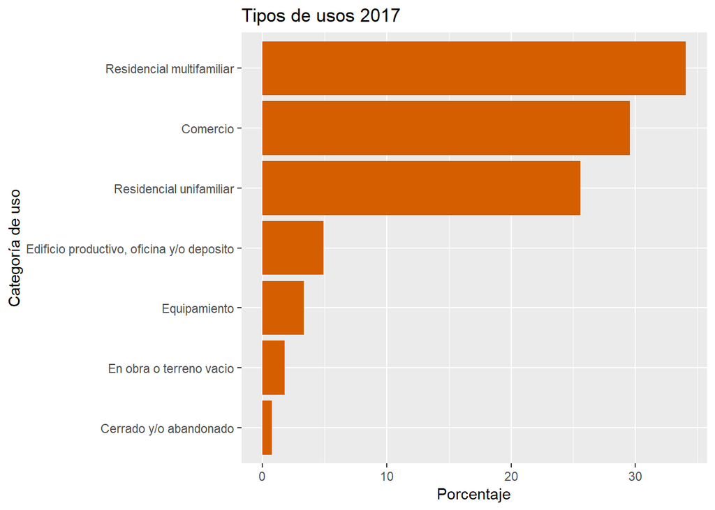

```r
ggplot(categorias_2017, aes(x=reorder(categoria, porcentaje_17), y= porcentaje_17)) +
  geom_bar(position="dodge", stat="identity", fill="#D55E00")+
  coord_flip()+
  labs(title = "Tipos de usos 2017",
         x = "Categoría de uso",
         y = "Porcentaje")
```

- Comparamos los valores de las distintas categorías de usos entre 2008 y 2017

```r
categorias_08_17 <- left_join(categorias_2008,categorias_2017)
```

```r
names(categorias_08_17)<-c("categoria", "cantidad_08", "total_08","RUS 2008", "cantidad_17", "total_17","RUS 2017")
```

```r
categorias_08_17_merge <- categorias_08_17 %>% gather(year, porcentaje, `RUS 2008`, `RUS 2017`)
```

```r
categorias_08_17_merge$porcentaje <-  round(categorias_08_17_merge$porcentaje,digits = 2)
```

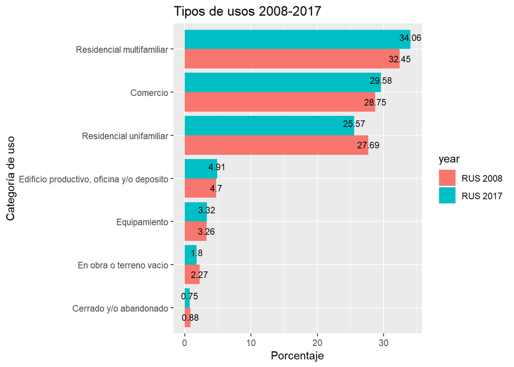

```r
ggplot(categorias_08_17_merge, aes(fill=year, y=porcentaje, x=reorder(categoria, porcentaje))) +
    geom_bar(position="dodge", stat="identity")+coord_flip() + labs(title = "Tipos de usos 2008-2017",
         x = "Categoría de uso",
         y = "Porcentaje")+geom_text(aes(label=porcentaje), vjust=0.3, colour="black", size=3,position = position_dodge(1))
```

El análisis de la totalidad de usos en la ciudad muestra que el mayor incremento se dio en el uso residencial multifamiliar, con un 1.61% y el mayor decrecimiento en el uso residencial unifamiliar con un 2.12%

#### Agrupación de usos por parcelas (smp)

El relevamiento de usos del suelo cuenta con un registro para cada tipo de uso encontrado en una parcela. Para poder realizar la comparación y evaluar la cantidad de parcelas que experimentaron algún tipo de cambio resulta necesario tener todos los usos en un único registro por parcela.

```r
rus17_parcela_1 <- rus2017_2 %>%
  group_by(smp) %>%
  summarise(barrio17 = first(BARRIO_17), cant = n(), pisos17 = mean(PISOS_17),
  CATEGORIA_17_GROUP= paste(sort(unique(CATEGORIA_17)), collapse = ","))
```

La tabla resultante queda del siguiente modo:

Usos 2017 agrupados por parcela.

| smp | barrio17 | cant | pisos17 | CATEGORIA_17_GROUP |
| --- | --- | --- | --- | --- |
| 001-002-022 | SAN NICOLAS | 2 | 2.0 | Comercio |
| 001-002-023 | SAN NICOLAS | 2 | 2.5 | Comercio,Edificio productivo, oficina y/o deposito |
| 001-002-024B | SAN NICOLAS | 1 | 3.0 | Equipamiento |
| 001-002-027 | SAN NICOLAS | 1 | 2.0 | Equipamiento |
| 001-002-028 | SAN NICOLAS | 2 | 2.5 | Comercio,Residencial multifamiliar |
| 001-002-029 | SAN NICOLAS | 1 | 5.0 | Equipamiento |
| 001-002-030 | SAN NICOLAS | 2 | 4.0 | Comercio,Residencial multifamiliar |
| 001-002-031 | SAN NICOLAS | 2 | 4.5 | Comercio,Residencial multifamiliar |
| 001-003A-001 | SAN NICOLAS | 1 | 11.0 | Equipamiento |
| 001-003A-002A | SAN NICOLAS | 1 | 2.0 | Edificio productivo, oficina y/o deposito |
| 001-003A-002B | SAN NICOLAS | 2 | 1.5 | Comercio,Residencial multifamiliar |

### Cambios entre RUS 2008 y 2017

#### Ajustes del parcelario

Para evaluar los cambios entre ambos períodos estudiados, unificamos el RUS 2008 y el RUS 2017 por parcela en una única base:

```r
rus08_17_1 <- left_join(rus17_parcela_1,rus08_parcela_1)
```

Se evalúan aquellas parcelas que no machearon por causa de una actualización del SMP y, en caso de que sea un número razonable, removerlas.

```r
sum(is.na(rus08_17_1$categoria_08_group))
```

```
## [1] 10503
```

Hay 10503 parcelas que no se unieron. Por conocimiento de la dinámica de los cambios en la nomenclatura catastral este número resulta razonable para el período estudiado, por lo tanto se eliminan. En un trabajo posterior habría que hacer una actualización de los smp del 2008.

```r
rus08_17_2 <- drop_na(rus08_17_1, categoria_08_group)
```

```r
sum(is.na(rus08_17_2$categoria_08_group))
```

```
## [1] 0
```

#### Parcelas que experimentaron cambios entre 2008 y 2017

Al tener los usos agrupados por parcela para 2008 y 2017 en una misma base, se pueden evaluar si para cada parcela el uso a 2017 es igual al del 2008. Si ambos son iguales se indica con un 0, y si son diferentes con un 1.

```r
rus08_17_3 <- mutate(rus08_17_2, cambio = ifelse(rus08_17_2$categoria_08_group==rus08_17_2$categoria_17_group,0,1))
```

Se genera una nueva capa donde solo están las parcelas que experimentaron algún tipo de cambio

```r
rus08_17_4 <- subset(rus08_17_3, cambio == "1")
```

Para poder evaluar que tipo de cambios se produjeron, es decir que uso reemplazó a que otro uso, se genera una nueva columna donde se unen los usos del 2008 y del 2017.

```r
rus08_17_4 <- mutate(rus08_17_4, cambios_08_17 = paste(categoria_08_group, categoria_17_group, sep = ";"))
```

La tabla resultante queda del siguiente modo:

Usos 2017 agrupados por parcela.

| smp | barrio | cantidad_17 | pisos_17 | categoria_17_group | cantidad_08 | pisos_08 | categoria_08_group | cambio | cambios_08_17 |
| --- | --- | --- | --- | --- | --- | --- | --- | --- | --- |
| 001-007A-025A | SAN NICOLAS | 2 | 3.0 | Edificio productivo, oficina y/o deposito,Equipamiento | 2 | 3.0 | Comercio,Edificio productivo, oficina y/o deposito | 1 | Comercio,Edificio productivo, oficina y/o deposito;Edificio productivo, oficina y/o deposito,Equipamiento |
| 001-008-006 | SAN NICOLAS | 2 | 1.0 | Comercio | 1 | 9.0 | Equipamiento | 1 | Equipamiento;Comercio |
| 001-008-028 | SAN NICOLAS | 3 | 4.0 | Comercio,Edificio productivo, oficina y/o deposito,Equipamiento | 3 | 4.0 | Comercio,Edificio productivo, oficina y/o deposito | 1 | Comercio,Edificio productivo, oficina y/o deposito;Comercio,Edificio productivo, oficina y/o deposito,Equipamiento |
| 001-008-030 | SAN NICOLAS | 2 | 1.5 | Comercio,Equipamiento | 2 | 1.5 | Comercio | 1 | Comercio;Comercio,Equipamiento |
| 001-009-009 | SAN NICOLAS | 1 | 2.0 | Equipamiento | 2 | 1.5 | Cerrado y/o abandonado,Comercio | 1 | Cerrado y/o abandonado,Comercio;Equipamiento |
| 001-009-012 | SAN NICOLAS | 1 | 8.0 | Equipamiento | 1 | 8.0 | Edificio productivo, oficina y/o deposito | 1 | Edificio productivo, oficina y/o deposito;Equipamiento |

#### Control de cambios según cantidad de pisos

- Se evalúa si hay diferencia de pisos en algunos tipos de cambios en los que se detectaron errores de relevamiento para 2008.

```r
rus08_17_4 <- mutate(rus08_17_4, diferencia_pisos = pisos_17-pisos_08)
```

- Se eliminan la filas en las que el cambio haya sido de residencial unifamiliar a residencial multifamiliar, pero no hubo cambio de pisos (se detectó un error de relevamiento en el RUS 2008).

```r
rus08_17_5 <- subset (rus08_17_4, rus08_17_4$cambios_08_17 != "Residencial unifamiliar;Residencial multifamiliar" | rus08_17_4$diferencia_pisos != 0)
```

- Se realiza el mismo tipo de análisis para el tipo de cambio “Residencial multifamiliar;Residencial unifamiliar” con altura igual a 0, ya que también se detectó el mismo tipo de error.

```r
rus08_17_6 <- subset (rus08_17_5, rus08_17_5$cambios_08_17 != "Residencial multifamiliar;Residencial unifamiliar" | rus08_17_5$diferencia_pisos != 0)
```

Entre 2008 y 2017, **31.095** parcelas de la ciudad experimentaron **algún tipo de cambio de uso**, es decir el **10% del total de las parcelas de la ciudad**.

#### Tipos de cambios 2008-2017

Finalmente estamos en condiciones de evaluar cuales son los tipos de cambios principales de usos, es decir “que uso cambió por cual otro uso”. El análisis arroja que hay **662** tipos de cambios diferentes ocurridos en un total de **31.095 parcelas**, de los cuales el 92% no se repite en más de 100 parcelas de la ciudad cada uno. Los primeros 20 tipos de cambios concentran las transformaciones ocurridas en el 50% del total de las parcelas que experimentaron algún tipo de cambio.

```r
Tipos_cambios_08_17_2 <- rus08_17_6 %>%
  group_by(cambios_08_17) %>%
  summarise(cantidad = n()) %>%
  arrange(desc(cantidad))
```

Por lo tanto se presentan los primeros 20 tipos de cambios:

Primeros 20 tipos de cambios de usos principales entre 2008 y 2017

| cambios_08_17 | cantidad |
| --- | --- |
| En obra o terreno vacio;Residencial multifamiliar | 2575 |
| Residencial unifamiliar;Residencial multifamiliar | 2455 |
| Comercio,Residencial multifamiliar;Residencial multifamiliar | 1135 |
| Residencial multifamiliar;Comercio,Residencial multifamiliar | 952 |
| Residencial unifamiliar;En obra o terreno vacio | 830 |
| Comercio,Residencial unifamiliar;Comercio,Residencial multifamiliar | 780 |
| Equipamiento;Edificio productivo, oficina y/o deposito | 634 |
| Comercio,Residencial unifamiliar;Residencial unifamiliar | 574 |
| En obra o terreno vacio;Residencial unifamiliar | 531 |
| Edificio productivo, oficina y/o deposito,Residencial multifamiliar;Comercio,Residencial multifamiliar | 523 |
| Residencial unifamiliar;Comercio,Residencial unifamiliar | 512 |
| Residencial unifamiliar;Cerrado y/o abandonado | 470 |
| Residencial multifamiliar,Residencial unifamiliar;Residencial multifamiliar | 468 |
| Comercio,Residencial unifamiliar;Residencial multifamiliar | 451 |
| Equipamiento;Comercio | 442 |
| Cerrado y/o abandonado;Residencial multifamiliar | 438 |
| Edificio productivo, oficina y/o deposito;Comercio | 408 |
| Residencial multifamiliar;En obra o terreno vacio | 385 |
| Comercio,Edificio productivo, oficina y/o deposito,Residencial multifamiliar;Comercio,Residencial multifamiliar | 374 |
| Residencial unifamiliar;Comercio | 364 |

Cinco primeros tipos de cambios de usos principales entre 2008 y 2017

| cambios_08_17 | cantidad |
| --- | --- |
| En obra o terreno vacio;Residencial multifamiliar | 2575 |
| Residencial unifamiliar;Residencial multifamiliar | 2455 |
| Comercio,Residencial multifamiliar;Residencial multifamiliar | 1135 |
| Residencial multifamiliar;Comercio,Residencial multifamiliar | 952 |
| Residencial unifamiliar;En obra o terreno vacio | 830 |

## Evaluación de los aspectos territoriales de los cambios

Una vez detectados los principales tipos de cambio de uso, resulta de interés analizar su distribución territorial a fin de detectar si existe algún tipo de patrón de distribución especial. Para este análisis se utilizan mapas de calor ya que nos permiten estudiar con mayor precisión la ubicación de los cambios principales respecto a otro tipo de visualizaciones basadas en límites administrativos como barrios y comunas o bien radios censales.

Para esto se incorpora la base de parcelas correspondiente al RUS 2017 por ser la más actualizada : *relevamiento-usos-del-suelo-2016-2017.shp* y se genera una nueva capa georreferenciada con las parcelas que experimentaron algún tipo de cambio, y los tipos de cambios. La capa se la incorpora como una capa de puntos.

```r
Cambios_0817_puntos <- left_join(Cambios_0817_puntos,rus08_17_6, by="smp")
```

Se eliminan las parcelas que no tuvieron cambios.

```r
Cambios_0817_puntos <- drop_na(Cambios_0817_puntos, categoria_08_group)
```

#### Distribución territorial de las parcelas que tuvieron algún tipo de cambio.

A continuación se presenta el mapa de calor resultante con las áreas de mayor concentración de parcelas con cambios de usos. Se observa una concentración de cambios entre los barrios de Palermo y Villa Crespo, sobre el eje de la avenida Rivadavia, en el entorno del cruce de las avenidas Nazca y Avellaneda, y en el entorno de la estación Juan Manuel de Rosas de la línea B de subte.

```r
leaflet(Cambios_0817_puntos) %>%
  addProviderTiles(providers$CartoDB.DarkMatter) %>%
  addWebGLHeatmap(lng=~Cambios_0817_puntos$x, lat=~Cambios_0817_puntos$y, size = 250)
```

[interactive chart not shown]

Distribución territorial de las área con mayor densidad de cambios de usos entre 2008 y 2017.

#### Distribución territorial de las parcelas que pasaron a ser vivienda multifamiliar.

Se extraen aquellas parcelas que a 2017 pasaron a tener uso residencial multifamiliar.

```r
Cambios_2017 <- rus08_17_6 %>%
  group_by(categoria_17_group) %>%
  summarise(cant = n())
```

```r
Multifamiliar_2017 <- subset(Cambios_0817_puntos,
                    categoria_17_group == "Residencial multifamiliar"|
                    categoria_17_group == "Comercio,Residencial multifamiliar"|
                    categoria_17_group == "Edificio productivo, oficina y/o deposito,Residencial multifamiliar"|
                    categoria_17_group == "Comercio,Edificio productivo, oficina y/o deposito,Residencial multifamiliar"|
                    categoria_17_group == "Equipamiento,Residencial multifamiliar"|
                    categoria_17_group == "Comercio,Equipamiento,Residencial multifamiliar"|
                    categoria_17_group == "En obra o terreno vacio,Residencial multifamiliar"|
                    categoria_17_group == "Comercio,En obra o terreno vacio,Residencial multifamiliar"|
                    categoria_17_group == "Cerrado y/o abandonado,Comercio,Residencial multifamiliar"|
                    categoria_17_group == "Comercio,Equipamiento,Residencial multifamiliar")
```

La cantidad de parcelas que pasan en 2017 a ser vivienda multifamiliar es de 14.448, es decir el **46%** del total de las parcelas que cambiaron entre 2008 y 2017, y el **4.5%** del total de las parcelas de la ciudad.

```r
summary(Multifamiliar_2017$cambios_08_17)
```

```
##    Length     Class      Mode
##     14448 character character
```

A continuación se observa el mapa de calor con la distribución de las parcelas que pasaron a tener uso residencial multifamiliar. Las áreas de mayor concentración de cambios detectadas en el mapa anterior coinciden con las áreas de mayor concentración del cambio hacia el uso residencial multifamiliar. La presencia de clusteres de vivienda multifamiliares en el entorno de la avenida General Paz, tradicionalmente de baja densidad, nos permite observar una tendencia a la transformación y densificación de áreas residenciales de vivienda unifamiliar.

```r
leaflet(Multifamiliar_2017) %>%
  addProviderTiles(providers$CartoDB.DarkMatter) %>%
  addWebGLHeatmap(lng=~Multifamiliar_2017$x, lat=~Multifamiliar_2017$y, size = 300)
```

[interactive chart not shown]

Distribución territorial de las área con mayor transformación hacia el uso residencial multifamiliar entre 2008 y 2017.

## Conclusiones

Entre 2008 y 2017 el 10% de las parcelas de la ciudad experimentaron algún tipo de cambio de uso. De ese 10% casi el 50% pasaron a ser vivienda multifamiliar. Este crecimiento de la vivienda multifamiliar se produce principalmente a expensas del decrecimiento de la vivienda unifamiliar: el 36% de las parcelas que pasaron a ser vivienda multifamiliar en 2017, en 2008 eran vivienda unifamiliar.

La mayor concentración de vivienda multifamiliar se dio en la intersección de los barrios de Palermo y Villa Crespo, al sur del barrio de Caballito, en el entorno de la estación Juan Manuel de Rosas de la línea B de subte en el barrio de Villa Urquiza, al sur de la estación de Liniers del ferrocarril General Sarmiento y en algunos sectores de los barrios que bordean la avenida General Paz.

Si bien el incremento del uso residencial multifamiliar corresponde al principal tipo de transformación detectado, se observan otro tipo de cambios como el incremento de los locales comerciales. Se deja para estudios posteriores el estudio de la dinámica de los cambios comerciales así como otro tipo de transformaciones vinculadas a la actividad económica.